# Contextual bandit algorithms

Jan Sviták, Rob van der Noll

January 28, 2020

In this notebook we present our contextual bandit algorithms where we add information about the competitor’s prices and let the firms make choices based on an estimated demand model.

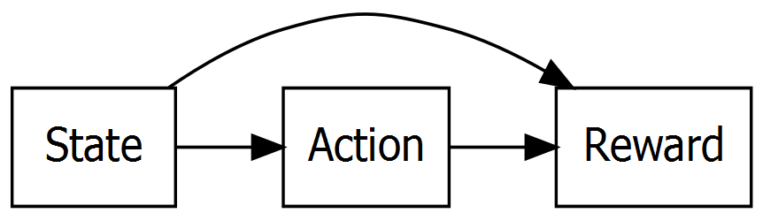

As is the case with the UCB1-tuned algorithms, also the contextual bandit algorithms will estimate expected reward for each available option. In this case it fill be based on their estimate of demand. As we experiment with different model specifications, we denote the firm $i$’s estimate of expected profit as $\hat{\pi}_{pt} = \hat{f}(p, p_t^{-i})$. $\hat{f}$ is the estimated function dependent on own and competitor’s prices.

The index determining which arm will get pulled is thus straightforward:

$$Q_p=\hat{\pi}_{pt}$$
To facilitate exploration, we use an $\epsilon$-greedy strategy and let the firms choose a price randomly with probability $e^{-0.0002t}$. For each algorithm, we run 100 experiments of 20000 periods. The exploration probability decreases with time, so the change of choosing a random price is approximately 90% at the beginning of each experiment and 13% after 10000 periods. We start with an initialisation of 500 randomly chosen prices.

We use two different demand specifications: neural network (deep contextual bandit) and linear regression (least squares contextual bandit)

## Deep contextual bandit

Our deep contextual bandits estimate a the expected rewards using a neural network with one hidden layer with two neurons and a logistic activation function and linear output:
$$y(x) = b_2+\sum_{i=1}^2w_{2i}g\left(b_{1i}+w_{1i}\sum_{j=1}^{20}g\left(b_{0j}+w_{0j}x_j\right)\right)$$
where $y$ is the expected profit as a function of $x$ containing information about the observed prices (20 dummy variables), $b_{lk}$ is the bias parameter for layer $l$ (0 = input, 1 = hidden, 2 = output) and input $k$ (neuron or element of input layer) and $w_{lk}$ is the weight parameter for layer $l$ and input $k$. The activation function $g()$ is specified as:
$$g(x)=\dfrac{1}{1+e^{-x}}$$
We define the activation and its derivative for later use.

```r
#extract function from neuralnet package
converted.fct <- neuralnet:::convert.activation.function("logistic")
#separate functions for activation and derivative
act.fct <- converted.fct$fct
act.deriv.fct <- converted.fct$deriv.fct
```

We can visualize the network with a diagram:

```r
net <- grViz("
digraph boxes_and_circles {

      # a 'graph' statement
      graph [overlap = true, fontsize = 10, layout = dot, rankdir = TB, ordering=out, ranksep = 2]

      # several 'node' statements
      subgraph cluster1{
        node [shape = box,
        fontname = Helvetica]
        'P1 = 0.1'; 'P1 = 0.2'; 'P1 = 0.3'; 'P1 = 0.4'; 'P1 = 0.5';
        'P1 = 0.6'; 'P1 = 0.7'; 'P1 = 0.8'; 'P1 = 0.9'; 'P1 = 1.0'
      }
      subgraph cluster2{
        node [shape = box,
        fontname = Helvetica]
        'P2 = 0.1'; 'P2 = 0.2'; 'P2 = 0.3'; 'P2 = 0.4'; 'P2 = 0.5';
        'P2 = 0.6'; 'P2 = 0.7'; 'P2 = 0.8'; 'P2 = 0.9'; 'P2 = 1.0'
      }
      node [shape = diamond,
      fontname = Helvetica, fontsize = 50, penwidth = 3]
      'Winst'
      node [shape = circle,
      fontname = Helvetica, fontsize = 30, penwidth = 3]
      'Neuron 1';'Neuron 2'

      # several 'edge' statements
      'P1 = 0.1'->{'Neuron 1' 'Neuron 2'}
      'P1 = 0.2'->{'Neuron 1' 'Neuron 2'}
      'P1 = 0.3'->{'Neuron 1' 'Neuron 2'}
      'P1 = 0.4'->{'Neuron 1' 'Neuron 2'}
      'P1 = 0.5'->{'Neuron 1' 'Neuron 2'}
      'P1 = 0.6'->{'Neuron 1' 'Neuron 2'}
      'P1 = 0.7'->{'Neuron 1' 'Neuron 2'}
      'P1 = 0.8'->{'Neuron 1' 'Neuron 2'}
      'P1 = 0.9'->{'Neuron 1' 'Neuron 2'}
      'P1 = 1.0'->{'Neuron 1' 'Neuron 2'}
      'P2 = 0.1'->{'Neuron 1' 'Neuron 2'}
      'P2 = 0.2'->{'Neuron 1' 'Neuron 2'}
      'P2 = 0.3'->{'Neuron 1' 'Neuron 2'}
      'P2 = 0.4'->{'Neuron 1' 'Neuron 2'}
      'P2 = 0.5'->{'Neuron 1' 'Neuron 2'}
      'P2 = 0.6'->{'Neuron 1' 'Neuron 2'}
      'P2 = 0.7'->{'Neuron 1' 'Neuron 2'}
      'P2 = 0.8'->{'Neuron 1' 'Neuron 2'}
      'P2 = 0.9'->{'Neuron 1' 'Neuron 2'}
      'P2 = 1.0'->{'Neuron 1' 'Neuron 2'}
      'Neuron 1'->'Winst'
      'Neuron 2'->'Winst'
      edge[style=invisible, arrowhead=none]
      'P1 = 0.1'->'P1 = 0.2'->'P1 = 0.3'->'P1 = 0.4'->'P1 = 0.5'->
      'P1 = 0.6'->'P1 = 0.7'->'P1 = 0.8'->'P1 = 0.9'->'P1 = 1.0'->
      'P2 = 0.1'->'P2 = 0.2'->'P2 = 0.3'->'P2 = 0.4'->'P2 = 0.5'->
      'P2 = 0.6'->'P2 = 0.7'->'P2 = 0.8'->'P2 = 0.9'->'P2 = 1.0'
      {rank=same;'P1 = 0.1'; 'P1 = 0.2'; 'P1 = 0.3'; 'P1 = 0.4'; 'P1 = 0.5';
      'P1 = 0.6'; 'P1 = 0.7'; 'P1 = 0.8'; 'P1 = 0.9'; 'P1 = 1.0';'P2 = 0.1';
      'P2 = 0.2'; 'P2 = 0.3'; 'P2 = 0.4'; 'P2 = 0.5';
      'P2 = 0.6'; 'P2 = 0.7'; 'P2 = 0.8'; 'P2 = 0.9'; 'P2 = 1.0'}
}
      ")
capture.output(rsvg_png(charToRaw(export_svg(net)), 'net.png', width = 862, height = 350))
```

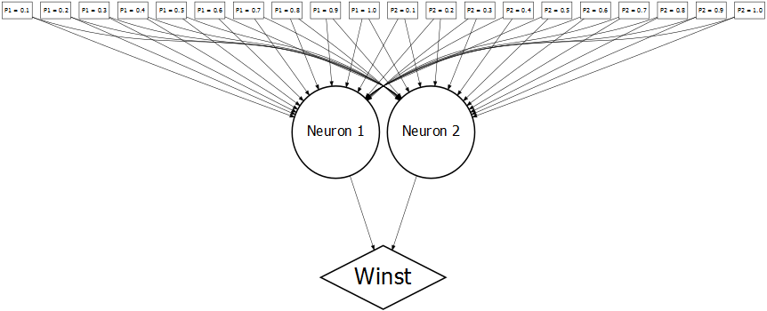

The estimates for the weights and biases are found by minimizing the quadratic cost:
$$\dfrac{1}{2n}\sum\|\pi-y(x)\|^2$$
where $\pi$ is the observed profit and $y(x)$ the output of the neural network.

We define the cost function and its derivative for later use:

```r
#extract the quadratic cost function from neuralnet package
converted.fct <- neuralnet:::convert.error.function("sse")
#separate functions for cost and its derivative
err.fct <- converted.fct$fct
err.deriv.fct <- converted.fct$deriv.fct
```

We proceed by writing the function carrying out the simulation:

```r
#inputs of the function are:
#   vector of available prices (P),
#   the intercept of the logit model (alpha)
#   the price sensitivity parameter of the logit model (beta)
#   learning rate for the backpropagation algorithm (lr)
#   number of iterations in one experiment (N)
#   number of experiments (MC)
#   lenght of initialisation period (init)
simulate_nn <- function(P, alpha, beta, lr, N, MC, init){
  #collect prices
  prices1 <- prices2 <- matrix(rep(NA, N*MC), N, MC)
  #collect profits
  profits1 <- profits2 <- matrix(rep(NA, N*MC), N, MC)
  #collect resulting estimates of the network
  models1 <- models2 <- list()
  #collect resulting payoff matrices
  Q1final <- Q2final <- list()
  #loop over experiments
  for (mc in 1:MC){
    #initialize
    #random pricing
    prices1[1:init, mc] <- sample(P, init, replace = TRUE)
    prices2[1:init, mc] <- sample(P, init, replace = TRUE)
    #calculate profits
    denom <- (1 + exp(alpha - beta * prices1[1:init, mc]) + exp(alpha - beta * prices2[1:init, mc]))
    profits1[1:init, mc] <- prices1[1:init, mc]*exp(alpha - beta * prices1[1:init, mc])/denom
    profits2[1:init, mc] <- prices2[1:init, mc]*exp(alpha - beta * prices2[1:init, mc])/denom
    #create matrices with 20 columns indicating which prices are set in which period
    X1 <- X2 <- matrix(0, init, 20)
    for(i in 1:init){
      X1[i,1:10] <- as.numeric(prices2[i, mc] == P)
      X1[i,11:20] <- as.numeric(prices1[i, mc] == P)
      X2[i,1:10] <- as.numeric(prices1[i, mc] == P)
      X2[i,11:20] <- as.numeric(prices2[i, mc] == P)
    }
    #combine with profits as dependent variable
    D1 <- as.data.frame(cbind(profits1[1:init, mc], X1))
    D2 <- as.data.frame(cbind(profits2[1:init, mc], X2))
    #estimate neural network with 2 neurons
    model1 <- neuralnet(paste("V1 ~ ", paste(names(D1[2:21]), collapse = "+")), D1,
                        hidden = c(2))
    #estimate neural network with 2 neurons
    model2 <- neuralnet(paste("V1 ~ ", paste(names(D2[2:21]), collapse = "+")), D2,
                        hidden = c(2))
    #calculate payoff matrix
    Q1 <- Q2 <- matrix(rep(NA, 100), 10, 10)
    #fill with predictions from neural network
    for(j in 1:10){
      newX <- cbind(matrix(0, 10, 10), diag(10))
      newX[, j] <- 1
      Q1[j,] <- predict(model1, newdata = newX)
      Q2[j,] <- predict(model2, newdata = newX)
    }
    #loop over periods
    for (t in (init + 1):N){
      #exploration probability
      eps <- exp(-0.0002*t)
      #exploration decision firm 1
      exp1 <- sample(c(0, 1), 1, prob = c(1-eps, eps))
      #explore (random price)
      if(exp1 == 1){
        pull1 <- sample(P, 1)
      }
      #choose best reponse to competitor's price in previous period
      else{
        pull1 <- sample(P[which.max(Q1[prices2[t-1, mc]*10,])], 1)
      }
      #exploration decision firm 2
      exp2 <- sample(c(0, 1), 1, prob = c(1-eps, eps))
      #explore (random price)
      if(exp2 == 1){
        pull2 <- sample(P, 1)
      }
      #choose best reponse to competitor's price in previous period
      else{
        pull2 <- sample(P[which.max(Q2[prices1[t-1, mc]*10,])], 1)
      }
      #calculate rewards
      reward1 <- pull1*exp(alpha - beta * pull1)/(1 + exp(alpha - beta * pull1) + exp(alpha - beta * pull2))
      reward2 <- pull2*exp(alpha - beta * pull2)/(1 + exp(alpha - beta * pull1) + exp(alpha - beta * pull2))
      #collect prices
      prices1[t, mc] <- pull1
      prices2[t, mc] <- pull2
      #collect profits
      profits1[t, mc] <- reward1
      profits2[t, mc] <- reward2
      #draw random periods for update of model (minibatch)
      set1 <- sample((init + 1):t, min(t- init, 100))
      set2 <- sample((init + 1):t, min(t- init, 100))
      #construct input layer
      X1 <- X2 <- matrix(0, length(set1), 20)
      for(i in 1:length(set1)){
        X1[i,1:10] <- as.numeric(prices2[set1 , mc][i] == P)
        X1[i,11:20] <- as.numeric(prices1[set1, mc][i] == P)
        X2[i,1:10] <- as.numeric(prices1[set2 , mc][i] == P)
        X2[i,11:20] <- as.numeric(prices2[set2, mc][i] == P)
      }
      #output layer
      y1 <- profits1[set1, mc]
      y2 <- profits2[set2, mc]
      #one backpropagation step for firm 1
      r1 <- neuralnet:::rprop(weights = model1$weights[[1]], response = y1, covariate = cbind(intercept = 1, X1),
                              threshold = 0.01, learningrate.factor = list(minus = 0.5, plus = 1.2),
                              stepmax = 2, lifesign = "none", lifesign.step = 1000, act.fct = act.fct,
                              act.deriv.fct = act.deriv.fct, err.fct = err.fct, err.deriv.fct = err.deriv.fct,
                              algorithm = "backprop", linear.output = TRUE, exclude = NULL,
                              learningrate.bp = lr/length(set1))
      #one backpropagation step for firm 2
      r2 <- neuralnet:::rprop(weights = model2$weights[[1]], response = y2, covariate = cbind(intercept = 1, X2),
                              threshold = 0.01, learningrate.factor = list(minus = 0.5, plus = 1.2),
                              stepmax = 2, lifesign = "none", lifesign.step = 1000, act.fct = act.fct,
                              act.deriv.fct = act.deriv.fct, err.fct = err.fct, err.deriv.fct = err.deriv.fct,
                              algorithm = "backprop", linear.output = TRUE, exclude = NULL,
                              learningrate.bp = lr/length(set2))
      #update weights and biases
      model1$weights[[1]] <- r1$weights
      model2$weights[[1]] <- r2$weights
      #update payoff matrices
      for(j in 1:10){
        newX <- cbind(matrix(0, 10, 10), diag(10))
        newX[, j] <- 1
        Q1[j,] <- predict(model1, newdata = newX)
        Q2[j,] <- predict(model2, newdata = newX)
      }
    }
    #collect models
    models1[[mc]] <- model1
    models2[[mc]] <- model2
    #collect final payoff matrices
    Q1final[[mc]] <- Q1
    Q2final[[mc]] <- Q2
  }
  #save results in the environment
  prices1 <<- prices1
  prices2 <<- prices2
  profits1 <<- profits1
  profits2 <<- profits2
  models1 <<- models1
  models2 <<- models2
  Q1final <<- Q1final
  Q2final <<- Q2final
}
```

We run 100 experiments of 20000 periods with initialization of 500 periods and learning rate of 0.5.

```r
#available prices
P <- seq(0.1, 1, 0.1)
#run
simulate_nn(P = P, alpha = 5, beta = 5, lr = 0.5, N = 20000, MC = 100, init = 500)
```

We will inspect the average estimates of the expected payoff matrix at the end of the experiment. This matrix determines what the firms view as an optimal reaction.

```r
#create data.frame with all combinations of prices
P_matrix <- data.frame(x1 = rep(P, each = length(P)),
                       x2 = rep(P, length(P)))
#calculate average estimated payoff from all 100 experiments
P_matrix$Qfinal <- as.vector(t(Reduce("+", Q1final) + Reduce("+", Q2final))/200)
```

Let’s visualise the resulting expected payoff matrix:

```r
#save as png
png(filename="Fig6.png", width=900, height=700, pointsize = 12, res = 150)
#start ggplot
ggplot() +
  #fill tiles according to estimated payoff
  geom_tile(data = P_matrix, aes(x = x2, y = x1, fill = Qfinal)) +
  #choose colour palette
  scale_fill_distiller(palette = "RdYlBu") +
  #add invisible layer to add optimal reaction to legend
  geom_point(data = data.frame(x = 1, y = 1, t = "Optimale reactie"), aes(x = x, y = y, color = t), shape = NA) +
  #set label and tickmarks y-axis
  scale_y_continuous(
    name = "Prijs van concurrent",
    breaks = seq(0.1, 1, 0.1),
    expand = c(0, 0)
  ) +
  #set label and tickmarks x-axis
  scale_x_continuous(
    name = "Beschikbare acties",
    breaks = seq(0.1, 1, 0.1),
    expand = c(0, 0)
  ) +
  #highlight optimal reactions
  geom_encircle(data = data.frame(x1 = rep(c(0.99, 1.01), 2),
                                  x2 = c(rep(0.69, 2), rep(0.71, 2))),
                aes(x = x2, y = x1),
                color="green2", s_shape=0.9,size=3, expand = 0.05) +
  geom_encircle(data = data.frame(x1 = rep(c(0.89, 0.91), 2),
                                  x2 = c(rep(0.59, 2), rep(0.61, 2))),
                aes(x = x2, y = x1),
                color="green2", s_shape=0.9,size=3, expand = 0.05) +
  geom_encircle(data = data.frame(x1 = rep(c(0.79, 0.81), 2),
                                  x2 = c(rep(0.59, 2), rep(0.61, 2))),
                aes(x = x2, y = x1),
                color="green2", s_shape=0.9,size=3, expand = 0.05) +
  geom_encircle(data = data.frame(x1 = rep(c(0.69, 0.71), 2),
                                  x2 = c(rep(0.49, 2), rep(0.51, 2))),
                aes(x = x2, y = x1),
                color="green2", s_shape=0.9,size=3, expand = 0.05) +
  geom_encircle(data = data.frame(x1 = rep(c(0.59, 0.61), 2),
                                  x2 = c(rep(0.49, 2), rep(0.51, 2))),
                aes(x = x2, y = x1),
                color="green2", s_shape=0.9,size=3, expand = 0.05) +
  geom_encircle(data = data.frame(x1 = rep(c(0.49, 0.51), 2),
                                  x2 = c(rep(0.39, 2), rep(0.41, 2))),
                aes(x = x2, y = x1),
                color="green2", s_shape=0.9,size=3, expand = 0.05) +
  geom_encircle(data = data.frame(x1 = rep(c(0.39, 0.41), 2),
                                  x2 = c(rep(0.39, 2), rep(0.41, 2))),
                aes(x = x2, y = x1),
                color="green2", s_shape=0.9,size=3, expand = 0.05) +
  geom_encircle(data = data.frame(x1 = rep(c(0.29, 0.31), 2),
                                  x2 = c(rep(0.39, 2), rep(0.41, 2))),
                aes(x = x2, y = x1),
                color="green2", s_shape=0.9,size=3, expand = 0.05) +
  geom_encircle(data = data.frame(x1 = rep(c(0.19, 0.21), 2),
                                  x2 = c(rep(0.29, 2), rep(0.31, 2))),
                aes(x = x2, y = x1),
                color="green2", s_shape=0.9,size=3, expand = 0.05) +
  geom_encircle(data = data.frame(x1 = rep(c(0.09, 0.11), 2),
                                  x2 = c(rep(0.29, 2), rep(0.31, 2))),
                aes(x = x2, y = x1),
                color="green2", s_shape=0.9,size=3, expand = 0.05) +
  #blank background
  theme(panel.background = element_rect(fill = NA),
        legend.key = element_blank()) +
  #adjust labels
  labs(fill = "Verwachte winst", color = "",
       title = "Gemiddelde verwachte winst aan het einde van experiment") +
  #adjust legend
  guides(
    #create legend key for optimal reactions
    color = guide_legend(
      override.aes = list(size = 10, stroke = 2, shape = 0, color = "green2"),
      order = 2
    ),
    #color at the top
    fill = guide_colourbar(order = 1)
  )
dev.off()
```

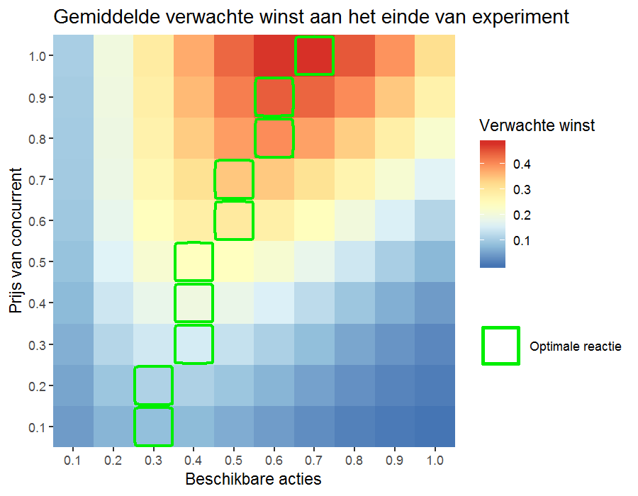

Plot simulation results: We can see that the payoffs very closely follow the theoretical values based on the true demand.

Let’s also visualise the results from the simulations:

```r
#load function
load("plot.RData")
#generate panels
plot_sim(prices1, prices2, P)
#construct left panel
tmp <- ggplot_gtable(ggplot_build(g1))
#identify element containing legend
leg <- which(sapply(tmp$grobs, function(x) x$name) == "guide-box")
#extract legend
legend <- tmp$grobs[[leg]]
```

```r
#arrange left and right panel with common legend underneath
png(filename = "Fig7.png", width = 1200, height = 650, pointsize = 12, res = 150)
grid.arrange(arrangeGrob(g1 + theme(legend.position = "none"),
                         g2 + theme(legend.position = "none"), nrow = 1),
             legend, nrow = 2, heights = c(10, 2))
dev.off()
```

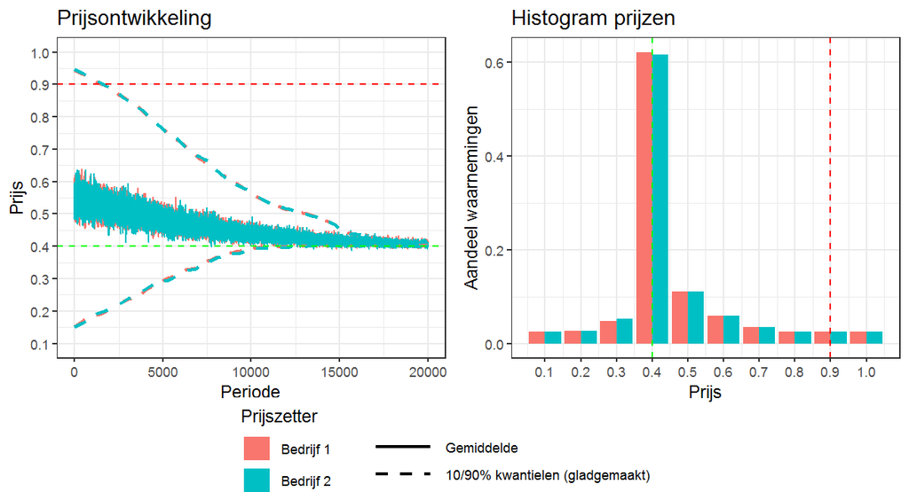

We can see that both the estimated payoff matrix and the simulation results lead to the Bertrand-Nash equilibrium. This is not suprising given the mechanics of the one-shot game and the precise estimates of the expected profits.

## Least squares contextual bandit

The least squares contextual bandit algorithms estimate a linear demand model:
$$d_i=a_i + b_i p_i + c_i p_{-i}$$
where $d_i$ is the volume sold by firm $i$, $p_i$ is the price of firm $i$ and $p_{-i}$ is the prices of the other firm.

The initial estimates of demand parameters are based on the initialisation period with random price setting. After initialization, the model is re-estimated every 500 periods using a minibatch of 500 randomly chosen observations.

We proceed by writing the function carrying out the simulation:

```r
#inputs of the function are:
#   vector of available prices (P),
#   the intercept of the logit model (alpha)
#   the price sensitivity parameter of the logit model (beta)
#   number of iterations in one experiment (N)
#   number of experiments (MC)
#   lenght of initialisation period (init)
simulate_ls <- function(P, alpha, beta, N, MC, init){
  #collect prices
  prices1 <- matrix(rep(NA, N*MC), N, MC)
  prices2 <- matrix(rep(NA, N*MC), N, MC)
  #collect profits
  profits1 <- matrix(rep(NA, N*MC), N, MC)
  profits2 <- matrix(rep(NA, N*MC), N, MC)
  #collect model estimates
  models1 <- models2 <- list()
  #loop over experiments
  for (mc in 1:MC){
    #initialize
    pull1 <- sample(P, init, replace = TRUE)
    pull2 <- sample(P, init, replace = TRUE)
    #calculate profits
    #denominator of logit demand function
    denom <- 1 + exp(alpha - beta * pull1) + exp(alpha - beta * pull2)
    #collect profits
    profits1[1:init, mc] <- pull1*exp(alpha - beta * pull1)/denom
    profits2[1:init, mc] <- pull2*exp(alpha - beta * pull2)/denom
    #collect prices
    prices1[1:init, mc] <- pull1
    prices2[1:init, mc] <- pull2
    #estimate linear demand
    model1 <- lm(y ~ x1 + x2,
                 data = data.frame(y = profits1[1:init, mc]/prices1[1:init, mc],
                                   x1 = prices1[1:init, mc],
                                   x2 = prices2[1:init, mc]))
    model2 <- lm(y ~ x1 + x2,
                 data = data.frame(y = profits2[1:init, mc]/prices2[1:init, mc],
                                   x1 = prices2[1:init, mc],
                                   x2 = prices1[1:init, mc]))
    #loop over time periods
    for (t in (init + 1):N){
      #exploration probability
      eps <- exp(-0.0002*t)
      #expected payoffs based on the model estimates given competitor's last price
      Q1 <- predict(model1, newdata = data.frame(x1 = P,
                                                 x2 = rep(prices2[t - 1, mc], length(P))))*P
      Q2 <- predict(model2, newdata = data.frame(x1 = P,
                                                 x2 = rep(prices1[t - 1, mc], length(P))))*P
      #exploration decision firm 1
      exp1 <- sample(c(0, 1), 1, prob = c(1-eps, eps))
      #explore (random price)
      if(exp1 == 1){
        pull1 <- sample(P, 1)
      }
      #choose best reponse
      else{
        pull1 <- sample(P[which.max(Q1)], 1)
      }
      #exploration decision firm 2
      exp2 <- sample(c(0, 1), 1, prob = c(1-eps, eps))
      #explore (random price)
      if(exp2 == 1){
        pull2 <- sample(P, 1)
      }
      #choose best response
      else{
        pull2 <- sample(P[which.max(Q2)], 1)
      }
      #calculate profits
      reward1 <- pull1*exp(alpha - beta * pull1)/(1 + exp(alpha - beta * pull1) + exp(alpha - beta * pull2))
      reward2 <- pull2*exp(alpha - beta * pull2)/(1 + exp(alpha - beta * pull1) + exp(alpha - beta * pull2))
      #collect prices
      prices1[t, mc] <- pull1
      prices2[t, mc] <- pull2
      #collect profits
      profits1[t, mc] <- reward1
      profits2[t, mc] <- reward2
      #update model every 500 periods
      if(t %% 500 == 0){
        #set minibatch
        set1 <- sample(1:t, 500)
        set2 <- sample(1:t, 500)
        #estimate linear model
        model1 <- lm(y ~ x1 + x2,
                     data = data.frame(y = profits1[set1, mc]/prices1[set1, mc],
                                       x1 = prices1[set1, mc],
                                       x2 = prices2[set1, mc]))
        model2 <- lm(y ~ x1 + x2,
                     data = data.frame(y = profits2[set2, mc]/prices2[set2, mc],
                                       x1 = prices2[set2, mc],
                                       x2 = prices1[set2, mc]))
      }
    }
    #collect model estimates
    models1[[mc]] <- model1
    models2[[mc]] <- model2
  }
  #save results into the environment
  prices1 <<- prices1
  prices2 <<- prices2
  profits1 <<- profits1
  profits2 <<- profits2
  models1 <<- models1
  models2 <<- models2
}
```

We run 100 experiments of 20000 periods with initialization of 500 periods.

```r
#run
simulate_ls(P = P, alpha = 5, beta = 5, N = 20000, MC = 100, init = 500)
```

Calculate the average expected payoff matrix use by the least squares bandit algorithm at the end of the experiment.

```r
#add a column for the index values
P_matrix$Q_ls <- 0
#loop over experiments
for(mc in 1:100){
  #add the expected payoff estimate based on the model of firm 1
  P_matrix$Q_ls <- P_matrix$Q_ls + predict(models1[[mc]],
                                             newdata = data.frame(x1 = rep(P, length(P)),
                                                                  x2 = rep(P, each = length(P))))*P/100
  #add the expected payoff estimate based on the model of firm 2
  P_matrix$Q_ls <- P_matrix$Q_ls + predict(models2[[mc]],
                                             newdata = data.frame(x1 = rep(P, length(P)),
                                                                  x2 = rep(P, each = length(P))))*P/100

}
```

Let’s visualise the resulting expected payoff matrix:

```r
#save as png
png(filename="Fig8.png", width=900, height=700, pointsize = 12, res = 150)
#start ggplot
ggplot() +
  #fill in tiles according to estimated payoffs
  geom_tile(data = P_matrix, aes(x = x2, y = x1, fill = Q_ls)) +
  #choose color palette
  scale_fill_distiller(palette = "RdYlBu") +
  #add invisible layer to add optimal reaction to legend
  geom_point(data = data.frame(x = 1, y = 1, t = "Optimale reactie"), aes(x = x, y = y, color = t), shape = NA) +
  #add invisible layer to add distinction between estimate/theory in the legend
  geom_line(data = data.frame(x = rep(1, 2), y = rep(1, 2), t = c("Schatting", "Theorie")),
            aes(x = x, y = y, lty = t)) +
  #estimates solid line, theory dotted line
  scale_linetype_manual(values = c(1, 3)) +
  #set label and tick marks for y-axis
  scale_y_continuous(
    name = "Prijs van concurrent",
    breaks = seq(0.1, 1, 0.1),
    expand = c(0, 0)
  ) +
  #set label and tick marks for x-axis
  scale_x_continuous(
    name = "Beschikbare acties",
    breaks = seq(0.1, 1, 0.1),
    expand = c(0, 0)
  ) +
  #highlight optimal reactions
  geom_encircle(data = data.frame(x1 = rep(c(0.99, 1.01), 2),
                                  x2 = c(rep(0.69, 2), rep(0.71, 2))),
                aes(x = x2, y = x1),
                color="green2", s_shape=0.9, size=3, expand = 0.05) +
  geom_encircle(data = data.frame(x1 = rep(c(0.89, 0.91), 2),
                                  x2 = c(rep(0.69, 2), rep(0.71, 2))),
                aes(x = x2, y = x1),
                color="green2", s_shape=0.9, size=3, expand = 0.05) +
  geom_encircle(data = data.frame(x1 = rep(c(0.79, 0.81), 2),
                                  x2 = c(rep(0.59, 2), rep(0.61, 2))),
                aes(x = x2, y = x1),
                color="green2", s_shape=0.9, size=3, expand = 0.05) +
  geom_encircle(data = data.frame(x1 = rep(c(0.69, 0.71), 2),
                                  x2 = c(rep(0.59, 2), rep(0.61, 2))),
                aes(x = x2, y = x1),
                color="green2", s_shape=0.9, size=3, expand = 0.05) +
  geom_encircle(data = data.frame(x1 = rep(c(0.59, 0.61), 2),
                                  x2 = c(rep(0.59, 2), rep(0.61, 2))),
                aes(x = x2, y = x1),
                color="green2", s_shape=0.9, size=3, expand = 0.05) +
  geom_encircle(data = data.frame(x1 = rep(c(0.49, 0.51), 2),
                                  x2 = c(rep(0.49, 2), rep(0.51, 2))),
                aes(x = x2, y = x1),
                color="green2", s_shape=0.9, size=3, expand = 0.05) +
  geom_encircle(data = data.frame(x1 = rep(c(0.39, 0.41), 2),
                                  x2 = c(rep(0.49, 2), rep(0.51, 2))),
                aes(x = x2, y = x1),
                color="green2", s_shape=0.9, size=3, expand = 0.05) +
  geom_encircle(data = data.frame(x1 = rep(c(0.29, 0.31), 2),
                                  x2 = c(rep(0.39, 2), rep(0.41, 2))),
                aes(x = x2, y = x1),
                color="green2", s_shape=0.9, size=3, expand = 0.05) +
  geom_encircle(data = data.frame(x1 = rep(c(0.19, 0.21), 2),
                                  x2 = c(rep(0.39, 2), rep(0.41, 2))),
                aes(x = x2, y = x1),
                color="green2", s_shape=0.9, size=3, expand = 0.05) +
  geom_encircle(data = data.frame(x1 = rep(c(0.09, 0.11), 2),
                                  x2 = c(rep(0.29, 2), rep(0.31, 2))),
                aes(x = x2, y = x1),
                color="green2", s_shape=0.9, size=3, expand = 0.05) +
  #highlight theoretical optimal reactions (where they deviate from estimates)
  geom_encircle(data = data.frame(x1 = rep(c(0.89, 0.91), 2),
                                  x2 = c(rep(0.59, 2), rep(0.61, 2))),
                aes(x = x2, y = x1),
                color="green2", s_shape=0.9, size=3, expand = 0.05, lty = 3) +
  geom_encircle(data = data.frame(x1 = rep(c(0.69, 0.71), 2),
                                  x2 = c(rep(0.49, 2), rep(0.51, 2))),
                aes(x = x2, y = x1),
                color="green2", s_shape=0.9, size=3, expand = 0.05, lty = 3) +
  geom_encircle(data = data.frame(x1 = rep(c(0.59, 0.61), 2),
                                  x2 = c(rep(0.49, 2), rep(0.51, 2))),
                aes(x = x2, y = x1),
                color="green2", s_shape=0.9, size=3, expand = 0.05, lty = 3) +
  geom_encircle(data = data.frame(x1 = rep(c(0.49, 0.51), 2),
                                  x2 = c(rep(0.39, 2), rep(0.41, 2))),
                aes(x = x2, y = x1),
                color="green2", s_shape=0.9, size=3, expand = 0.05, lty = 3) +
  geom_encircle(data = data.frame(x1 = rep(c(0.39, 0.41), 2),
                                  x2 = c(rep(0.39, 2), rep(0.41, 2))),
                aes(x = x2, y = x1),
                color="green2", s_shape=0.9, size=3, expand = 0.05, lty = 3) +
  geom_encircle(data = data.frame(x1 = rep(c(0.19, 0.21), 2),
                                  x2 = c(rep(0.29, 2), rep(0.31, 2))),
                aes(x = x2, y = x1),
                color="green2", s_shape=0.9, size=3, expand = 0.05, lty = 3) +
  #blank background
  theme(panel.background = element_rect(fill = NA),
        legend.key = element_blank()) +
  #adjust labels
  labs(fill = "Verwachte winst", color = "", lty = "",
       title = "Gemiddelde verwachte winst aan het einde van experiment") +
  #adjust legend
  guides(
    #create legend key for optimal reactions
    color = guide_legend(
      override.aes = list(size = 10, stroke = 2, shape = 0, color = "green2"),
      order = 2
    ),
    #color at the top
    fill = guide_colourbar(order = 1),
    #legend for estimted/theoretical optimal reaction
    linetype = guide_legend(
      override.aes = list(lwd = 1, keywidth = unit(10,"cm"), color = "green2")
    )
  )
dev.off()
```

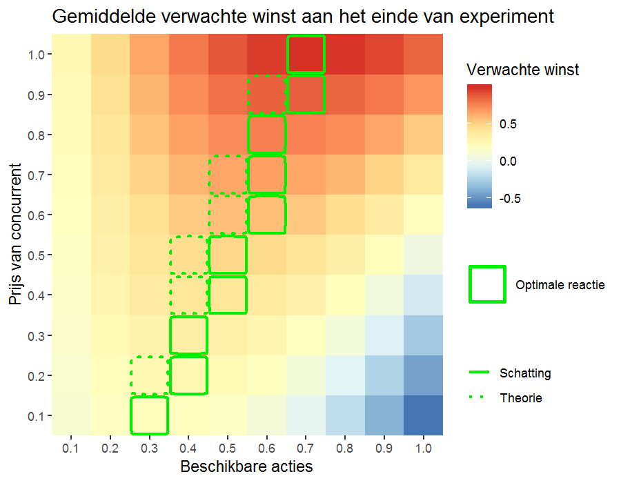

The misspecification of the linear demand model clearly lead to a shift in reaction functions of the firms.

We will also look at the development of prices in the experiments:

```r
#generate panels
plot_sim(prices1, prices2, P)
#legend the same as in case of deep contextual bandit
```

```r
#arrange left and right panel with common legend underneath
png(filename = "Fig9.png", width = 1200, height = 650, pointsize = 12, res = 150)
grid.arrange(arrangeGrob(g1 + theme(legend.position = "none"),
                         g2 + theme(legend.position = "none"), nrow = 1),
             legend, nrow = 2, heights = c(10, 2))
dev.off()
```

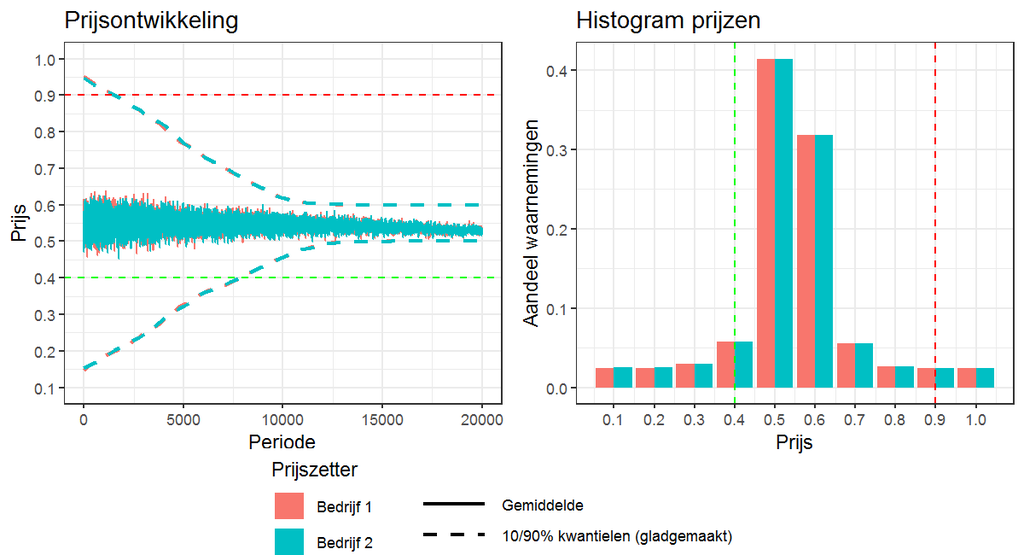

As we could expect from the expected payoff matrix, the firms converge to the prices of 0.5 or 0.6 which are both above the competitive level of 0.4.